# Melody in Motion

```python
# Hide Code Cells
from IPython.display import HTML
HTML('''
<script
    src="https://cdnjs.cloudflare.com/ajax/libs/jquery/2.0.3/jquery.min.js ">
</script>
<script>
code_show=true;
function code_toggle() {
 if (code_show){
 $('div.jp-CodeCell > div.jp-Cell-inputWrapper').hide();
 } else {
$('div.jp-CodeCell > div.jp-Cell-inputWrapper').show();
 }
 code_show = !code_show
}
$( document ).ready(code_toggle);
</script>
<form action="javascript:code_toggle()"><input type="submit"
    value="Click here to toggle on/off the raw code."></form>
''')
```

[figure not shown]

## Table of Contents

Executive Summary  
Import Libraries

**SECTIONS**

Section I. Problem Statement  
Section II. Motivation  
Section III. Data Source and Description  
Section IV. Methodology

- Exploratory Data Analysis and Preprocessing
- Statatistical Testing and Transformation
- Soft Clustering

Section V. Results and Discussion

- Clustering Results
- Trend Analyis

Section VI. Conclusion  
Section VII. Recommendations  
Section VIII. References

**TABLES**

Table 1. Summary Table of Feature Descriptions  
Table 2. Methodology Details  
Table 3. Information Table of Features with Pandas Datatype and Valid Data  
Table 4. Dataset Sorted by `track`  
Table 5. Summary of Transformation Done based from Statistical Test

**FIGURES**

Figure 1. Methodology  
Figure 2. Plotting Trends of Number of Trackand Unique Artists per Decade  
Figure 3. Word Cloud Visualization of Spotify Artists  
Figure 4. Plotting the Histograms of Data Features  
Figure 5. Correlation Matrix of Continuous Features  
Figure 6. Correlation Matrix of Transformed Features  
Figure 7. Scatter Plot of Transformed Data using First and Second Principal Components  
Figure 8. Scatter Plot of Clustered Data using the Best Clustering Model from Grid Search  
Figure 9. Plotting Number of Songs according to Number of Acceptable Label/Cluster  
Figure 10. Distribution of Predicted Clusters  
Figure 11. Cluster 0 - Eclectic Mix  
Figure 12. Cluster 1 - Serene Melodies  
Figure 13. Cluster 2 - Energetic Bliss  
Figure 14. Cluster 3 - Vibrant Melodies  
Figure 15. Cluster 4 - Mellow Ensembles  
Figure 16. Word Cloud Representation of Most Recurring Artists in the Cluster  
Figure 17. Number of Songs in each Cluster and decade segmented by Hit or Flop

## Executive Summary

This analysis on the Spotify dataset employed a four-step methodology. Firstly, exploratory data analysis and preprocessing techniques were utilized to understand the relationships between variables and address any data issues. Statistical testing and transformations were then applied to assess data normality and transform variables if necessary. Soft clustering using Gaussian Mixture Modeling was conducted to identify overlapping or fuzzy clusters within the dataset. Finally, trend analysis was performed to examine the evolving characteristics of hit songs over time within the identified clusters.  
With these methods, we were able to identify that songs that get the audience moving and energized with their danceable beats and fast tempo are trending nowadays. Artists, producers, and marketers can leverage these findings to inform their creative decisions, promotional strategies, and target audience identification. Overall, this clustering analysis contributes to a better understanding of the underlying patterns and trends within Spotify hit songs, enabling stakeholders to make data-driven decisions and navigate the dynamic music landscape more effectively.

Back to Table of Contents

## Importing Libraries

In this section, the relevant Python Libraries and Python Modules were imported. The different functions or methods associated with these libraries are necessary for the analysis or maintenance of this report.

```python
# Importing Libraries
import os, re, time, glob
import numpy as np
import pandas as pd
import matplotlib.pyplot as plt
import seaborn as sns
from wordcloud import WordCloud

from scipy import stats

from sklearn.pipeline import Pipeline
from sklearn.preprocessing import StandardScaler
from sklearn.decomposition import PCA
from sklearn.model_selection import GridSearchCV
from sklearn.mixture import GaussianMixture
from sklearn.metrics import (
    make_scorer,
    calinski_harabasz_score,
    davies_bouldin_score,
    silhouette_score,
)

from pyjanitor import auto_toc
from pickling import *

toc = auto_toc(
    fig_num = 1,
    figures= {
        1: 'Methodology',
    },
    table_num = 2,
    tables= {
        1: 'Summary Table of Feature Descriptions',
        2: 'Methodology Details',
    },
    header_bg='#1db954',
    header_color='#121212',
    font_size=14,
)
```

[output not shown]

Back to Table of Contents

## Problem Statement

Loving music knows no age. Great songs can come from different times but as generations pass, music trends and hit songs composition change. The goal of this clustering analysis is to identify distinct clusters or groups within the Spotify hit songs dataset based on various audio and metadata features. By doing so, we aim to uncover patterns and similarities among successful songs and gain insights into the characteristics that contribute to their popularity.  
The team seeks to gain a deeper understanding of the underlying factors that contribute to the success of Spotify hit songs and potentially uncover valuable insights for artists, music producers, and the music industry as a whole. Specifically, the team aims to solve the problem statement:  
*How do we identify clusters and align them with the evolving trends and preferences in the music industry over time?*

Back to Table of Contents

## Motivation

Analyzing and understanding the characteristics of Spotify hit songs through clustering analysis holds significant value for various stakeholders in the music industry.  
By understanding the patterns and trends within hit songs, artists can tailor their creative decisions and marketing strategies to align with audience preferences, potentially increasing their chances of achieving commercial success.  
Additionally, music streaming platforms, such as Spotify, can benefit from clustering analysis by enhancing their recommendation systems. By grouping songs into distinct clusters based on shared attributes, these platforms can provide personalized and accurate recommendations to users, leading to increased user engagement and satisfaction.  
Overall, the motivation behind conducting clustering analysis on Spotify hit songs lies in uncovering the underlying patterns, trends, and factors that contribute to a song's success. By doing so, this analysis can inform and benefit artists, music platforms, marketers, researchers, and the music industry as a whole, leading to more informed decision-making and potentially driving innovation in the creation, distribution, and promotion of music.

Back to Table of Contents

## Data Source and Description

For this analysis, The Spotify Hit Predictor Dataset from Kaggle was utilized. The dataset was scraped using Spotify's Web API by Farooq Ansari [1].

The Spotify dataset is available in the form of Comma-Separated Values (CSV) files, which were downloaded from the following link: https://www.kaggle.com/datasets/theoverman/the-spotify-hit-predictor-dataset?select=dataset-of-10s.csv.

Below is a summary table of the features available in the dataset.

Feature Name

Feature Description

Data Type

danceability

Danceability describes how suitable a track is for dancing based on a combination of musical elements including tempo, rhythm stability, beat strength, and overall regularity. A value of 0.0 is least danceable and 1.0 is most danceable.

Numeric

energy

Energy is a measure from 0.0 to 1.0 and represents a perceptual measure of intensity and activity. Typically, energetic tracks feel fast, loud, and noisy. For example, death metal has high energy, while a Bach prelude scores low on the scale. Perceptual features contributing to this attribute include dynamic range, perceived loudness, timbre, onset rate, and general entropy.

Numeric

key

The estimated overall key of the track. Integers map to pitches using standard Pitch Class notation. E.g. 0 = C, 1 = C#/Db, 2 = D, and so on. If no key was detected, the value is -1.

Numeric

loudness

The overall loudness of a track in decibels (dB). Loudness values are averaged across the entire track and are useful for comparing relative loudness of tracks. Loudness is the quality of a sound that is the primary psychological correlate of physical strength (amplitude). Values typical range between -60 and 0 db.

Numeric

mode

Mode indicates the modality (major or minor) of a track, the type of scale from which its melodic content is derived. Major is represented by 1 and minor is 0.

Binary

speechiness

Speechiness detects the presence of spoken words in a track. The more exclusively speech-like the recording (e.g. talk show, audio book, poetry), the closer to 1.0 the attribute value. Values above 0.66 describe tracks that are probably made entirely of spoken words. Values between 0.33 and 0.66 describe tracks that may contain both music and speech, either in sections or layered, including such cases as rap music. Values below 0.33 most likely represent music and other non-speech-like tracks.

Numeric

acousticness

A confidence measure from 0.0 to 1.0 of whether the track is acoustic. 1.0 represents high confidence the track is acoustic.

Numeric

instrumentalness

Predicts whether a track contains no vocals. “Ooh” and “aah” sounds are treated as instrumental in this context. Rap or spoken word tracks are clearly “vocal”. The closer the instrumentalness value is to 1.0, the greater likelihood the track contains no vocal content. Values above 0.5 are intended to represent instrumental tracks, but confidence is higher as the value approaches 1.0.

Numeric

liveness

Detects the presence of an audience in the recording. Higher liveness values represent an increased probability that the track was performed live. A value above 0.8 provides strong likelihood that the track is live.

Numeric

valence

A measure from 0.0 to 1.0 describing the musical positiveness conveyed by a track. Tracks with high valence sound more positive (e.g. happy, cheerful, euphoric), while tracks with low valence sound more negative (e.g. sad, depressed, angry).

Numeric

tempo

The overall estimated tempo of a track in beats per minute (BPM). In musical terminology, tempo is the speed or pace of a given piece and derives directly from the average beat duration.

Numeric

duration_ms

The duration of the track in milliseconds.

Numeric

time_signature

An estimated overall time signature of a track. The time signature (meter) is a notational convention to specify how many beats are in each bar (or measure).

Numeric

chorus_hit

This the source's best estimate of when the chorus would start for the track. Its the timestamp of the start of the third section of the track. This feature was extracted from the data received by the API call for Audio Analysis of that particular track.

Numeric

sections

The number of sections the particular track has. This feature was extracted from the data received by the API call for Audio Analysis of that particular track.

Numeric

target

The target variable for the track. It can be either '0' or '1'. '1' implies that this song has featured in the weekly list (Issued by Billboards) of Hot-100 tracks in that decade at least once and is therefore a 'hit'. '0' Implies that the track is a 'flop'.  
The condition of a track being 'flop' is as follows:

- The track must not appear in the 'hit' list of that decade.
- The track's artist must not appear in the 'hit' list of that decade.
- The track must belong to a genre that could be considered non-mainstream and / or avant-garde.
- The track's genre must not have a song in the 'hit' list.
- The track must have 'US' as one of its markets.

Binary

**Table 1.** Summary Table of Feature Descriptions.

Back to Table of Contents

## Methodology

As outlined below in **Figure 1. Methodology**, our analysis consists of four steps. The analysis begins with Exploratory Data Analysis and Preprocessing, followed by Statistiscal Testing and Transformations, then Soft Clustering, and finally, Trend Analysis.  
Refer to **Table 2: Methodology Details** for more details about each step.

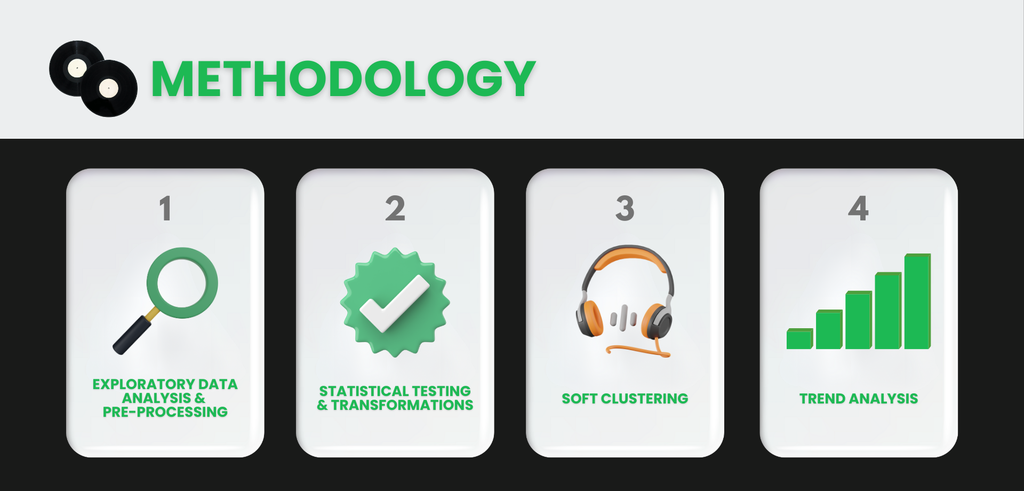

**Figure 1.** Methodology.

| Step | Description |
| --- | --- |
| Exploratory Data Analysis and Preprocessing | Descriptive statistics, data visualizations, and correlation analysis are used to understand the relationships between different variables. Missing values, outliers, and inconsistencies are addressed … |
| Statistiscal Testing and Transformations | Statistical tests are employed to assess the normality of the data. If required, variables were transformed using log transformation. |
| Soft Clustering | Gaussian Mixture Modeling was employed in this step. This approach allows for the exploration of overlapping or fuzzy clusters within the dataset. The optimal number of clusters is determined using ev… |
| Trend Analysis | In this step, trends within the identified clusters are analyzed to gain insights into the evolving characteristics of Spotify hit songs over time. The results were visualized for consumption. |

**Table 2.** Methodology Details.

Back to Table of Contents

### Exploratory Data Analysis and Preprocessing

In this section, we investigate the data and visualize the findings for close observation. The data was first loaded, merged together with their corresponding decade, and was further cleaned by dropping duplicates. The team investigated the health of the dataset and visualized some trends to extract information regarding its general composition.  
The distribution of features were then plotted and observed. Upon investigation, more features were set as categorical. The team then conducted correlation visualization and dropped a feature that is highly correlated to another.

```python
# Load the Files and Merge
files = glob.glob('./data/*.csv')

# merge all datafiles, append a decade marker
df = pd.DataFrame()
for file in files:
    df_loop = pd.read_csv(file)
    df_loop['decade'] = file.split('/')[-1][11:14]
    df = pd.concat([df, df_loop])

# drop duplicates, keep first instance
df.drop_duplicates(subset='uri', keep='first', inplace=True)
```

```python
# display health
info_dict = {'feature': df.columns, 'data_type': df.dtypes,
             'non-null_count': df.count()}

df_info = pd.DataFrame(info_dict).reset_index(drop=True)

toc.add_table(df_info,
              'Information Table of Features with Pandas Datatype'
              ' and Valid Data',
              index=False,
              border=False,
              preview=False)
```

| feature | data_type | non-null_count |
| --- | --- | --- |
| track | object | 40560 |
| artist | object | 40560 |
| uri | object | 40560 |
| danceability | float64 | 40560 |
| energy | float64 | 40560 |
| key | int64 | 40560 |
| loudness | float64 | 40560 |
| mode | int64 | 40560 |
| speechiness | float64 | 40560 |
| acousticness | float64 | 40560 |
| instrumentalness | float64 | 40560 |
| liveness | float64 | 40560 |
| valence | float64 | 40560 |
| tempo | float64 | 40560 |
| duration_ms | int64 | 40560 |
| time_signature | int64 | 40560 |
| chorus_hit | float64 | 40560 |
| sections | int64 | 40560 |
| target | int64 | 40560 |
| decade | object | 40560 |

**Table 3.** Information Table of Features with Pandas Datatype and Valid Data.

*.*

**Insights:**  
Checking the over-all health/density of the dataset. There no null values.

```python
# set decade marker as a categorical variable, for sorting
decades = ['60s', '70s', '80s', '90s', '00s', '10s']
df['decade'] = pd.Categorical(df['decade'], categories=decades)
df.sort_values('decade', inplace=True)
```

```python
# plotting number of tracks & number of unique artists per decade
tracks_per_decade = df.groupby('decade')['uri'].count()
unique_artists_per_decade = df.groupby('decade')['artist'].nunique()

fig, axs = plt.subplots(1, 2, figsize=(15, 8))

tracks_per_decade.plot(kind='bar', color='#1DB954', ax=axs[0])
axs[0].set_title('Number of Tracks per Decade', fontsize=16)
axs[0].set_xlabel('Decade')
axs[0].set_ylabel('Count')
axs[0].tick_params(axis='x', rotation=0)
axs[0].spines['top'].set_visible(False)
axs[0].spines['right'].set_visible(False)

unique_artists_per_decade.plot(kind='bar', color='#48494B', ax=axs[1])
axs[1].set_title('Number of Unique Artists per Decade', fontsize=16)
axs[1].set_xlabel('Decade')
axs[1].set_ylabel('Count')
axs[1].tick_params(axis='x', rotation=0)
axs[1].spines['top'].set_visible(False)
axs[1].spines['right'].set_visible(False)

toc.add_fig('Plotting Trends of Number of Track'
            'and Unique Artists per Decade',
            width=100)
```

[figure not shown]

**Figure 2.** Plotting Trends of Number of Trackand Unique Artists per Decade.

*.*

**Insights:**  
Observing some temporal trends in the dataset. It can be observed that the number of tracks experienced a dip during the 90's. However, the Number of Unique Artists are in upward trend, increasing as time passes.

```python
# spotify artists in the dataset
artist_names = ' '.join(df['artist'].str.lower().dropna().astype(str))

wordcloud = WordCloud(width=800, height=400,
                      background_color='white').generate(artist_names)

plt.figure(figsize=(15, 8))
plt.imshow(wordcloud, interpolation='bilinear')

plt.axis('off')
plt.title('Spotify Artists', fontsize=18)

toc.add_fig('Word Cloud Visualization of Spotify Artists', width=100)
```

[figure not shown]

**Figure 3.** Word Cloud Visualization of Spotify Artists.

*.*

**Insights:**  
Based on the given word cloud, the biggest words are "featuring," "traditional," "Harry Belafonte," "Ennio Morricone," and "P Susheela." The presence of "featuring" suggests that collaborations between artists are prominent in the Spotify dataset. This indicates that many songs on Spotify feature multiple artists working together, which has become a common trend in the music industry. Other artists who have a significant presence in the dataset encompass a diverse range of musical backgrounds and styles.

```python
# Checking counts
display(HTML(
    f"""
    <div style='text-align: justify; font-size:15px;'>
    There are {len(df)} tracks in the dataset.
    <br>
    Number of unique track names: {df['track'].nunique()}
    </div>
    """
))

toc.add_table(df[df['track'].duplicated(keep=False)].sort_values(by='track'),
              'Dataset Sorted by `track`',
              index=False,
              border=False)
```

There are 40560 tracks in the dataset.  
Number of unique track names: 35792

| track | artist | uri | danceability | energy | key | loudness | mode | speechiness | acousticness | instrumentalness | liveness | valence | tempo | duration_ms | time_signature | chorus_hit | sections | target | decade |
| --- | --- | --- | --- | --- | --- | --- | --- | --- | --- | --- | --- | --- | --- | --- | --- | --- | --- | --- | --- |
| 'Buked and Scorned' | Big Joe Williams | spotify:track:4aGBRXIuMVigUiNLtgtIQQ | 0.452000 | 0.239000 | 4 | -17.514000 | 0 | 0.046300 | 0.689000 | 0.000195 | 0.682000 | 0.673000 | 92.399000 | 322173 | 4 | 50.144610 | 14 | 0 | 70s |
| 'Buked and Scorned' | Big Joe Williams | spotify:track:4AyNhn1NCyUsVNThVgkVbS | 0.452000 | 0.239000 | 4 | -17.514000 | 0 | 0.046300 | 0.689000 | 0.000195 | 0.682000 | 0.673000 | 92.399000 | 322173 | 4 | 50.144610 | 14 | 0 | 70s |
| 'Round Midnight | Sonny Rollins | spotify:track:6SSan65dVwcf6sYLeKk74u | 0.424000 | 0.205000 | 10 | -13.869000 | 0 | 0.029000 | 0.905000 | 0.780000 | 0.124000 | 0.164000 | 97.331000 | 239707 | 4 | 23.078020 | 11 | 0 | 60s |
| 'Round Midnight | Gerald Wilson Orchestra | spotify:track:4UWMQXm1PW88Cef9is3oY5 | 0.503000 | 0.227000 | 3 | -16.926000 | 0 | 0.031400 | 0.844000 | 0.665000 | 0.103000 | 0.208000 | 109.100000 | 312893 | 4 | 26.915970 | 13 | 0 | 60s |
| 'Round Midnight | McCoy Tyner | spotify:track:5r69JaKNfc9GlS23ye9W2D | 0.541000 | 0.177000 | 3 | -19.927000 | 0 | 0.049300 | 0.947000 | 0.901000 | 0.079400 | 0.237000 | 62.656000 | 382800 | 4 | 94.321030 | 13 | 0 | 60s |
| (I Can't Get No) Satisfaction | Sky Saxon | spotify:track:2i1YPp8eXjusze5OD9OI4f | 0.531000 | 0.850000 | 2 | -5.379000 | 1 | 0.041500 | 0.003100 | 0.000000 | 0.153000 | 0.739000 | 134.945000 | 236947 | 4 | 40.802120 | 7 | 0 | 00s |
| (I Can't Get No) Satisfaction | The Rolling Stones | spotify:track:2PzU4IB8Dr6mxV3lHuaG34 | 0.723000 | 0.863000 | 2 | -7.890000 | 1 | 0.033800 | 0.038300 | 0.031700 | 0.128000 | 0.931000 | 136.302000 | 222813 | 4 | 27.497370 | 11 | 1 | 60s |
| (I Know) I'm Losing You | Rare Earth | spotify:track:18bZGZU0wZ2lV1SEDoXqqr | 0.463000 | 0.553000 | 6 | -14.648000 | 1 | 0.046500 | 0.573000 | 0.000037 | 0.315000 | 0.715000 | 100.608000 | 215987 | 4 | 28.639160 | 9 | 1 | 70s |
| (I Know) I'm Losing You | The Temptations | spotify:track:6y8o4V2R2dSt2ijgL8C72W | 0.634000 | 0.503000 | 5 | -11.890000 | 1 | 0.028200 | 0.500000 | 0.000000 | 0.046500 | 0.813000 | 109.570000 | 149493 | 4 | 44.357410 | 7 | 1 | 60s |
| (I'm Not Your) Steppin' Stone | The Monkees | spotify:track:7dvtNWoHd3ioEBmIl0s3In | 0.537000 | 0.677000 | 5 | -4.437000 | 1 | 0.030100 | 0.015100 | 0.000199 | 0.098100 | 0.324000 | 131.477000 | 146533 | 4 | 52.303940 | 7 | 1 | 60s |

**Table 4.** Preview of Dataset Sorted by `track`.

*.*

**Insights:**  
The discrepancy between the total number of tracks and the number of unique track names in the Spotify dataset suggests that there are duplicate track names present in the data. Upon visual inspection, it appears that some duplicated track names in the Spotify dataset have the same audio features, indicating that they are identical recordings of the same song. However, there are also instances where duplicate track names have different audio features, even though they are attributed to the same artist.  
This variation in audio features could be due to different versions or editions of the same song, remixes, covers, live performances, or other variations. It is common for artists to release multiple versions of a track with different arrangements, production styles, or featured artists. The dataset may also include tracks with different artists but the same track name.

```python
# inspect all numeric columns
num_variables = [col for col in df.describe().columns if col != 'target']

fig, axs = plt.subplots(3, 5, figsize=(15, 8))

for i, ax in enumerate(axs.flat):
    var = num_variables[i]
    target_1 = df.loc[df['target'] == 1, var]
    target_0 = df.loc[df['target'] == 0, var]

    x_min = min(target_1.min(), target_0.min())
    x_max = max(target_1.max(), target_0.max())

    bins = np.linspace(x_min, x_max, 30)

    ax.hist(target_1, bins=bins, edgecolor='black', color='#1db954',
            alpha=0.8, label='Hit')

    ax.hist(target_0, bins=bins, edgecolor='black', color='#535353',
            alpha=0.6, label='Flop')

    ax.set_title(var)
    ax.legend(loc='upper right')

plt.suptitle('Distribution of Features', fontsize=18)
plt.tight_layout()

toc.add_fig('Plotting the Histograms of Data Features', width=100)
```

[figure not shown]

**Figure 4.** Plotting the Histograms of Data Features.

*.*

**Insights:**  
Apart from target, the following variables can be considered discrete or categorical:

- key: Represents the musical key of a track
- mode: Indicates the modality of a track (major or minor)
- time_signature: Represents the time signature of a track

Detailed descriptions are available in [Spotify's Web API Reference](https://developer.spotify.com/documentation/web-api/reference/get-several-audio-features).

```python
# Set continuous and categorical features
cat_columns = ['target', 'key', 'mode', 'time_signature']
cont_columns = [
    col for col in df.describe().columns if col not in cat_columns
]
```

```python
# Check correlations of continuous features
corr_matrix = df[cont_columns].corr()

plt.figure(figsize=(10, 10))

sns.heatmap(corr_matrix, cmap='YlGn', annot=True, fmt=".2f", cbar=True,
            square=True, annot_kws={"size": 10})

plt.xticks(rotation=90)
plt.yticks(rotation=0)

toc.add_fig('Correlation Matrix of Continuous Features', width=100)
```

[figure not shown]

**Figure 5.** Correlation Matrix of Continuous Features.

*.*

**Insights:**  
At this point, we can drop loudness as it is highly correlated with energy.

```python
# Drop `loudness`
# df.drop(columns=['loudness'], inplace=True)
cont_columns = [
    col for col in cont_columns if col != 'loudness'
]
```

Back to Table of Contents

### Statistiscal Testing and Transformations

Since the team aims to perform clustering using GMM, categorical features were not utilized and continuous features were prepared. In this section, the team automated the Statistical Testing process and applied Log Transformation if necessary.

```python
# to automate normal tests + transformations
transformations = {
    'log': np.log,
    'reciprocal': lambda x: 1 / x,
    'boxcox': stats.boxcox
}

df_transformed = df.copy()
transformed_features = {}

for col in cont_columns:
    data = df[col].copy()

    _, p_value = stats.normaltest(df[col])

    if p_value < 0.05:
        for transformation, transform_func in transformations.items():
            try:
                if transformation == 'log':
                    transformed_ft = transform_func(data + 1e-10)
                else:
                    transformed_ft = transform_func(data)
                df_transformed[col + '_' + transformation] = transformed_ft

                transformed_features[col] = {
                    'transformation': transformation,
                    'transformed_feature': transformed_ft
                }

                break
            except (ValueError, ZeroDivisionError):
                continue
    else:
        transformed_features[col] = {
            'transformation': 'none',
            'transformed_feature': df[col]
        }

df_transformation = (
    pd.DataFrame()
    .from_dict(transformed_features, orient='index')
    .drop(columns='transformed_feature')
    .rename_axis('feature')
)
# for col, info in transformed_features.items():
#     print(f"Feature: {col}, Transformation: {info['transformation']}")
toc.add_table(df_transformation,
              'Summary of Transformation Done based from Statistical Test',
              index=True,
              border=False,
              preview=False)
```

| feature | transformation |
| --- | --- |
| danceability | log |
| energy | log |
| speechiness | log |
| acousticness | log |
| instrumentalness | log |
| liveness | log |
| valence | log |
| tempo | log |
| duration_ms | log |
| chorus_hit | log |
| sections | log |

**Table 5.** Summary of Transformation Done based from Statistical Test.

*.*

**Insights:**  
All the continuous features were Log Transformed.

```python
# consistent correlations (no need to show this in the report)
trans_columns = [f'{col}_log' for col in cont_columns]
trans_corr_matrix = df_transformed[trans_columns].corr()

plt.figure(figsize=(10, 10))
sns.heatmap(trans_corr_matrix, cmap='YlGn', annot=True, fmt=".2f", cbar=True,
            square=True, annot_kws={"size": 10})
plt.xticks(rotation=90)
plt.yticks(rotation=0)

toc.add_fig('Correlation Matrix of Transformed Features', width=100)
```

[figure not shown]

**Figure 6.** Correlation Matrix of Transformed Features.

*.*

**Insights:**  
Checking the correlation of the remaining continuous features. All the remaining continuous features are now ready for clustering. There are no more remaining highly correlated features.

Back to Table of Contents

### Soft Clustering

By this point, the data is now ready for clustering. The team employed the use of GridSearchCV to optimize the implementation of GaussianMixture with respect to the clusters' silhouette_score. The team included Standard Scaler in the pipeline as standard scaling ensures that all features have similar scales and prevents variables with larger magnitudes from dominating the clustering process. Pickle files were loaded for streamlined run of analysis.

```python
# Plotting the Data
pca = PCA(random_state=1337)
df_pca = pca.fit_transform(df_transformed[trans_columns])
fig, ax = plt.subplots(figsize=(15,8))
sns.scatterplot(
    x=df_pca[:, 0], y=df_pca[:, 1],
    color='#1DB954', ec='#191414'
)
plt.xlabel('PC1')
plt.ylabel('PC2')

toc.add_fig('Scatter Plot of Transformed Data using'
            ' First and Second Principal Components',
            width=100)
```

[figure not shown]

**Figure 7.** Scatter Plot of Transformed Data using First and Second Principal Components.

*.*

**Insights:**  
Plotted the transformed data using its Principal Components. It is observable that there are already visible clustering found in the dataset.

```python
# Performing Grid-Search
def silhouette_scorer(estimator, X):
    """
    Scoring function for silhouette_score inside GridSearchCV.
    """
    labels = estimator.predict(X)
    score = silhouette_score(X, labels)
    return score

rng = np.random.RandomState(143)

param_grid = dict(
    clusterer__n_components=range(5, 11),
    clusterer__reg_covar=[1e-6, 1e-5, 1e-4],
    clusterer__init_params=['kmeans', 'random_from_data'],
)

fixed_params = dict(
    covariance_type='full',
    max_iter=100,
    n_init=1,
    random_state=rng,
    verbose=0,
    verbose_interval=20,
)

scoring = {'silhouette': silhouette_scorer}

gmm = GaussianMixture(**fixed_params)

scaler = StandardScaler()
pipe = Pipeline([('scaler', scaler), ('clusterer', gmm)])

gs = GridSearchCV(
    estimator=pipe,
    param_grid=param_grid,
    cv=[(slice(None), slice(None))],
    scoring=scoring,
    refit='silhouette',
    verbose=3,
)
```

```python
# Try and load saved pickle file
try:
    gs = load_pkl('best-gmm.pkl')
except:
    gs.fit(df_transformed[usecols])
    save_pkl(gs, 'best-gmm.pkl')
```

```python
# Plot results of best clustering
fig, ax = plt.subplots(figsize=(15,8))
sns.scatterplot(
    x=df_pca[:, 0], y=df_pca[:, 1],
    hue=gs.predict(df_transformed[trans_columns]),
    palette='colorblind'
)
plt.xlabel('PC1')
plt.ylabel('PC2')

toc.add_fig('Scatter Plot of Clustered Data using'
            ' the Best Clustering Model from Grid Search',
            width=100)
```

[figure not shown]

**Figure 8.** Scatter Plot of Clustered Data using the Best Clustering Model from Grid Search.

*.*

**Insights:**  
The grid of models were evaluated and the best performing clustering model was selected based on its silhouette_score. Using the best clustering model from the performed grid search, the best number of clusters is 5. Plotting the clusters, it is observable that there overlaps but the clusters are visibly dense.

```python
df_transformed['predicted_label'] = gs.predict(df_transformed[trans_columns])
df_transformed['label'] = df['target']

soft_labels = gs.predict_proba(df_transformed[trans_columns])
threshold = 1 / soft_labels.shape[1]
indices_above_threshold = np.argwhere(soft_labels > threshold)

df_transformed['soft_labels'] = (
    pd.DataFrame(indices_above_threshold).groupby(0)[1].apply(list)
)

multilabel_counts = (
    pd.DataFrame(indices_above_threshold)
    .groupby(0)[1]
    .apply(list)
    .apply(len)
    .value_counts()
)
fig, ax = plt.subplots(figsize=(15,6))
multilabel_counts.plot.bar(color='#1db954', ec='#535353')
plt.xlabel('Number of Labels')
plt.ylabel('Count')
plt.xticks(rotation=0)

for i, count in enumerate(multilabel_counts):
    plt.text(i, count + 100, str(count), ha='center', va='bottom')

toc.add_fig('Plotting Number of Songs according to'
            ' Number of Acceptable Label/Cluster',
            width=100)
```

[figure not shown]

**Figure 9.** Plotting Number of Songs according to Number of Acceptable Label/Cluster.

*.*

**Insights:**  
Plotting the number of songs based on the number of acceptable label, it is observable that the most of the data points affiliate with only 1 cluster label, some affiliate to two, but there are minimal number of songs with 3 acceptable labels. Acceptability is determined by a set threshold.

```python
df['predicted_label'] = df_transformed.predicted_label

fig, ax = plt.subplots(figsize=(15,7))
df.predicted_label.value_counts().sort_index().plot.bar(color='#1db954')
plt.xticks(rotation=0)
ax.set_xlabel('Cluster')
ax.set_ylabel('Count')

toc.add_fig('Distribution of Predicted Clusters', width=100)
```

[figure not shown]

**Figure 10.** Distribution of Predicted Clusters.

*.*

**Insights:**  
The clustering done was relatively balanced with the exception of Cluster 0. Cluster 0's size is significantly smaller than the rest of the clusters.

Back to Table of Contents